# Risk Factor Analysis

## Outcome Variable

**Outcome Variable:** sstunted

## Predictor Variables

**Intervention Variable:** gagebrth

**Adjustment Set:**

unadjusted

## Stratifying Variables

The analysis was stratified on these variable(s):

- agecat
- studyid
- country

## Data Summary

| agecat | studyid | country | gagebrth | sstunted | n_cell | n |
| --- | --- | --- | --- | --- | --- | --- |
| Birth | CMC-V-BCS-2002 | INDIA | Full or late term | 0 | 55 | 92 |
| Birth | CMC-V-BCS-2002 | INDIA | Full or late term | 1 | 3 | 92 |
| Birth | CMC-V-BCS-2002 | INDIA | Preterm | 0 | 10 | 92 |
| Birth | CMC-V-BCS-2002 | INDIA | Preterm | 1 | 1 | 92 |
| Birth | CMC-V-BCS-2002 | INDIA | Early term | 0 | 23 | 92 |
| Birth | CMC-V-BCS-2002 | INDIA | Early term | 1 | 0 | 92 |
| Birth | COHORTS | GUATEMALA | Full or late term | 0 | 338 | 617 |
| Birth | COHORTS | GUATEMALA | Full or late term | 1 | 3 | 617 |
| Birth | COHORTS | GUATEMALA | Preterm | 0 | 91 | 617 |
| Birth | COHORTS | GUATEMALA | Preterm | 1 | 4 | 617 |
| Birth | COHORTS | GUATEMALA | Early term | 0 | 179 | 617 |
| Birth | COHORTS | GUATEMALA | Early term | 1 | 2 | 617 |
| Birth | COHORTS | INDIA | Full or late term | 0 | 562 | 1293 |
| Birth | COHORTS | INDIA | Full or late term | 1 | 8 | 1293 |
| Birth | COHORTS | INDIA | Preterm | 0 | 269 | 1293 |
| Birth | COHORTS | INDIA | Preterm | 1 | 16 | 1293 |
| Birth | COHORTS | INDIA | Early term | 0 | 431 | 1293 |
| Birth | COHORTS | INDIA | Early term | 1 | 7 | 1293 |
| Birth | COHORTS | PHILIPPINES | Full or late term | 0 | 1161 | 3024 |
| Birth | COHORTS | PHILIPPINES | Full or late term | 1 | 3 | 3024 |
| Birth | COHORTS | PHILIPPINES | Preterm | 0 | 618 | 3024 |
| Birth | COHORTS | PHILIPPINES | Preterm | 1 | 31 | 3024 |
| Birth | COHORTS | PHILIPPINES | Early term | 0 | 1199 | 3024 |
| Birth | COHORTS | PHILIPPINES | Early term | 1 | 12 | 3024 |
| Birth | IRC | INDIA | Full or late term | 0 | 228 | 369 |
| Birth | IRC | INDIA | Full or late term | 1 | 10 | 369 |
| Birth | IRC | INDIA | Preterm | 0 | 33 | 369 |
| Birth | IRC | INDIA | Preterm | 1 | 3 | 369 |
| Birth | IRC | INDIA | Early term | 0 | 93 | 369 |
| Birth | IRC | INDIA | Early term | 1 | 2 | 369 |

[output cut: 144 more lines]

The following strata were considered:

- agecat: 24 months, studyid: CMC-V-BCS-2002, country: INDIA
- agecat: 24 months, studyid: COHORTS, country: GUATEMALA
- agecat: 24 months, studyid: COHORTS, country: INDIA
- agecat: 24 months, studyid: COHORTS, country: PHILIPPINES
- agecat: 24 months, studyid: IRC, country: INDIA
- agecat: 24 months, studyid: JiVitA-3, country: BANGLADESH
- agecat: 24 months, studyid: Keneba, country: GAMBIA
- agecat: 24 months, studyid: NIH-Crypto, country: BANGLADESH
- agecat: 24 months, studyid: PROBIT, country: BELARUS
- agecat: 24 months, studyid: TanzaniaChild2, country: TANZANIA, UNITED REPUBLIC OF
- agecat: 6 months, studyid: CMC-V-BCS-2002, country: INDIA
- agecat: 6 months, studyid: COHORTS, country: GUATEMALA
- agecat: 6 months, studyid: COHORTS, country: INDIA
- agecat: 6 months, studyid: COHORTS, country: PHILIPPINES
- agecat: 6 months, studyid: IRC, country: INDIA
- agecat: 6 months, studyid: JiVitA-3, country: BANGLADESH
- agecat: 6 months, studyid: Keneba, country: GAMBIA
- agecat: 6 months, studyid: NIH-Crypto, country: BANGLADESH
- agecat: 6 months, studyid: PROBIT, country: BELARUS
- agecat: 6 months, studyid: TanzaniaChild2, country: TANZANIA, UNITED REPUBLIC OF
- agecat: Birth, studyid: CMC-V-BCS-2002, country: INDIA
- agecat: Birth, studyid: COHORTS, country: GUATEMALA
- agecat: Birth, studyid: COHORTS, country: INDIA
- agecat: Birth, studyid: COHORTS, country: PHILIPPINES
- agecat: Birth, studyid: IRC, country: INDIA
- agecat: Birth, studyid: JiVitA-3, country: BANGLADESH
- agecat: Birth, studyid: Keneba, country: GAMBIA
- agecat: Birth, studyid: NIH-Crypto, country: BANGLADESH
- agecat: Birth, studyid: PROBIT, country: BELARUS

### Dropped Strata

Some strata were dropped due to rare outcomes:

- agecat: Birth, studyid: CMC-V-BCS-2002, country: INDIA
- agecat: Birth, studyid: COHORTS, country: GUATEMALA
- agecat: Birth, studyid: COHORTS, country: PHILIPPINES
- agecat: Birth, studyid: IRC, country: INDIA
- agecat: Birth, studyid: NIH-Crypto, country: BANGLADESH
- agecat: Birth, studyid: PROBIT, country: BELARUS
- agecat: 6 months, studyid: IRC, country: INDIA
- agecat: 6 months, studyid: Keneba, country: GAMBIA
- agecat: 6 months, studyid: NIH-Crypto, country: BANGLADESH
- agecat: 6 months, studyid: TanzaniaChild2, country: TANZANIA, UNITED REPUBLIC OF
- agecat: 24 months, studyid: NIH-Crypto, country: BANGLADESH
- agecat: 24 months, studyid: PROBIT, country: BELARUS
- agecat: 24 months, studyid: TanzaniaChild2, country: TANZANIA, UNITED REPUBLIC OF

## Methods Detail

We’re interested in the causal parameters $E[Y_a]$ for all values of $a \in \mathcal{A}$. These parameters represent the mean outcome if, possibly contrary to fact, we intervened to set all units to have $A=a$. Under the randomization and positivity assumptions, these are identified by the statistical parameters $\psi_a=E_W[E_{Y|A,W}(Y|A=a,W)]$. In addition, we’re interested in the mean of $Y$, $E[Y]$ under no intervention (the observed mean). We will estimate these parameters by using SuperLearner to fit the relevant likelihood factors – $E_{Y|A,W}(Y|A=a,W)$ and $p(A=a|W)$, and then updating our likelihood fit using a joint TMLE.

For unadjusted analyses ($W=\{\}$), initial likelihoods were estimated using Lrnr_glm to estimate the simple $E(Y|A)$ and Lrnr_mean to estimate $p(A)$. For adjusted analyses, a small library containing Lrnr_glmnet, Lrnr_xgboost, and Lrnr_mean was used.

Having estimated these parameters, we will then use the delta method to estimate relative risks and attributable risks relative to a prespecified baseline level of $A$.

# Results Detail

## Results Plots

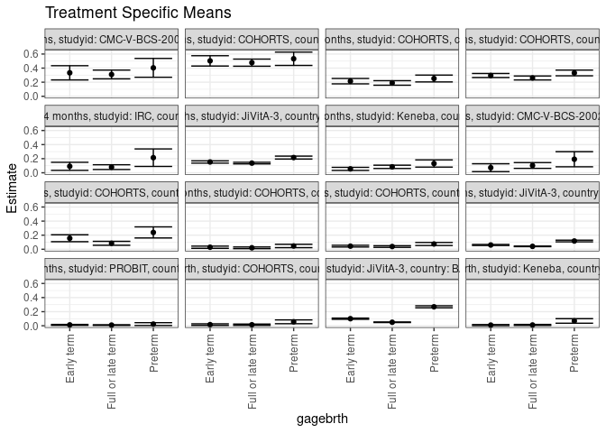

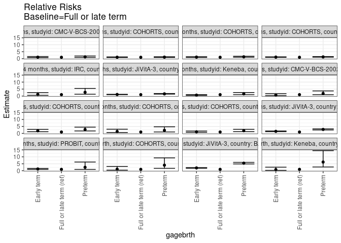

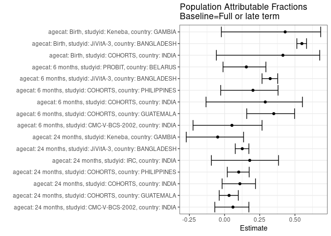

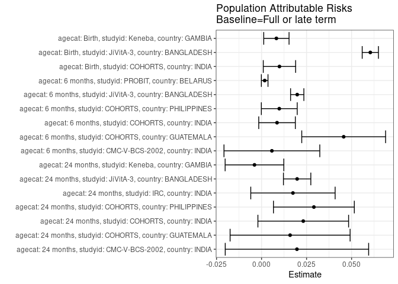

## Results Table

### Parameter: TSM

| agecat | studyid | country | intervention_level | baseline_level | estimate | ci_lower | ci_upper |
| --- | --- | --- | --- | --- | --- | --- | --- |
| Birth | COHORTS | INDIA | Full or late term | NA | 0.0140351 | 0.0043742 | 0.0236960 |
| Birth | COHORTS | INDIA | Preterm | NA | 0.0561404 | 0.0294051 | 0.0828756 |
| Birth | COHORTS | INDIA | Early term | NA | 0.0159817 | 0.0042330 | 0.0277305 |
| Birth | JiVitA-3 | BANGLADESH | Full or late term | NA | 0.0495249 | 0.0451285 | 0.0539212 |
| Birth | JiVitA-3 | BANGLADESH | Preterm | NA | 0.2691626 | 0.2550613 | 0.2832639 |
| Birth | JiVitA-3 | BANGLADESH | Early term | NA | 0.1002674 | 0.0918696 | 0.1086652 |
| Birth | Keneba | GAMBIA | Full or late term | NA | 0.0108992 | 0.0033854 | 0.0184130 |
| Birth | Keneba | GAMBIA | Preterm | NA | 0.0680851 | 0.0358691 | 0.1003011 |
| Birth | Keneba | GAMBIA | Early term | NA | 0.0091575 | 0.0011649 | 0.0171501 |
| 6 months | CMC-V-BCS-2002 | INDIA | Full or late term | NA | 0.1037736 | 0.0626625 | 0.1448847 |
| 6 months | CMC-V-BCS-2002 | INDIA | Preterm | NA | 0.1923077 | 0.0850337 | 0.2995817 |
| 6 months | CMC-V-BCS-2002 | INDIA | Early term | NA | 0.0722892 | 0.0164963 | 0.1280820 |
| 6 months | COHORTS | GUATEMALA | Full or late term | NA | 0.0848329 | 0.0571246 | 0.1125412 |
| 6 months | COHORTS | GUATEMALA | Preterm | NA | 0.2389381 | 0.1602577 | 0.3176184 |
| 6 months | COHORTS | GUATEMALA | Early term | NA | 0.1563981 | 0.1073529 | 0.2054433 |
| 6 months | COHORTS | INDIA | Full or late term | NA | 0.0211268 | 0.0092958 | 0.0329577 |
| 6 months | COHORTS | INDIA | Preterm | NA | 0.0468227 | 0.0228679 | 0.0707776 |
| 6 months | COHORTS | INDIA | Early term | NA | 0.0292135 | 0.0135609 | 0.0448661 |
| 6 months | COHORTS | PHILIPPINES | Full or late term | NA | 0.0389105 | 0.0270870 | 0.0507341 |
| 6 months | COHORTS | PHILIPPINES | Preterm | NA | 0.0750436 | 0.0534677 | 0.0966195 |
| 6 months | COHORTS | PHILIPPINES | Early term | NA | 0.0441989 | 0.0319724 | 0.0564254 |
| 6 months | JiVitA-3 | BANGLADESH | Full or late term | NA | 0.0412806 | 0.0370583 | 0.0455029 |
| 6 months | JiVitA-3 | BANGLADESH | Preterm | NA | 0.1172414 | 0.1054608 | 0.1290220 |
| 6 months | JiVitA-3 | BANGLADESH | Early term | NA | 0.0606129 | 0.0530982 | 0.0681275 |
| 6 months | PROBIT | BELARUS | Full or late term | NA | 0.0094917 | 0.0041798 | 0.0148035 |
| 6 months | PROBIT | BELARUS | Preterm | NA | 0.0235935 | 0.0036912 | 0.0434958 |
| 6 months | PROBIT | BELARUS | Early term | NA | 0.0122188 | 0.0056335 | 0.0188041 |
| 24 months | CMC-V-BCS-2002 | INDIA | Full or late term | NA | 0.3098592 | 0.2476675 | 0.3720509 |
| 24 months | CMC-V-BCS-2002 | INDIA | Preterm | NA | 0.4038462 | 0.2702922 | 0.5374001 |
| 24 months | CMC-V-BCS-2002 | INDIA | Early term | NA | 0.3333333 | 0.2323789 | 0.4342877 |
| 24 months | COHORTS | GUATEMALA | Full or late term | NA | 0.4773333 | 0.4267410 | 0.5279256 |
| 24 months | COHORTS | GUATEMALA | Preterm | NA | 0.5327103 | 0.4381032 | 0.6273174 |
| 24 months | COHORTS | GUATEMALA | Early term | NA | 0.5027933 | 0.4294917 | 0.5760949 |
| 24 months | COHORTS | INDIA | Full or late term | NA | 0.1893805 | 0.1570609 | 0.2217001 |
| 24 months | COHORTS | INDIA | Preterm | NA | 0.2524590 | 0.2036863 | 0.3012318 |
| 24 months | COHORTS | INDIA | Early term | NA | 0.2146119 | 0.1761486 | 0.2530751 |
| 24 months | COHORTS | PHILIPPINES | Full or late term | NA | 0.2601279 | 0.2320472 | 0.2882086 |
| 24 months | COHORTS | PHILIPPINES | Preterm | NA | 0.3313840 | 0.2906429 | 0.3721252 |
| 24 months | COHORTS | PHILIPPINES | Early term | NA | 0.2949640 | 0.2663043 | 0.3236237 |
| 24 months | IRC | INDIA | Full or late term | NA | 0.0800000 | 0.0463276 | 0.1136724 |
| 24 months | IRC | INDIA | Preterm | NA | 0.2142857 | 0.0900319 | 0.3385396 |
| 24 months | IRC | INDIA | Early term | NA | 0.0918367 | 0.0345858 | 0.1490877 |
| 24 months | JiVitA-3 | BANGLADESH | Full or late term | NA | 0.1372776 | 0.1257913 | 0.1487639 |
| 24 months | JiVitA-3 | BANGLADESH | Preterm | NA | 0.2157107 | 0.1949168 | 0.2365047 |
| 24 months | JiVitA-3 | BANGLADESH | Early term | NA | 0.1532365 | 0.1369008 | 0.1695721 |
| 24 months | Keneba | GAMBIA | Full or late term | NA | 0.0843806 | 0.0612872 | 0.1074740 |
| 24 months | Keneba | GAMBIA | Preterm | NA | 0.1317365 | 0.0804201 | 0.1830530 |
| 24 months | Keneba | GAMBIA | Early term | NA | 0.0555556 | 0.0339460 | 0.0771651 |

### Parameter: E(Y)

| agecat | studyid | country | intervention_level | baseline_level | estimate | ci_lower | ci_upper |
| --- | --- | --- | --- | --- | --- | --- | --- |
| Birth | COHORTS | INDIA | NA | NA | 0.0239753 | 0.0156340 | 0.0323165 |
| Birth | JiVitA-3 | BANGLADESH | NA | NA | 0.1099244 | 0.1052719 | 0.1145770 |
| Birth | Keneba | GAMBIA | NA | NA | 0.0191419 | 0.0122398 | 0.0260440 |
| 6 months | CMC-V-BCS-2002 | INDIA | NA | NA | 0.1095101 | 0.0766059 | 0.1424143 |
| 6 months | COHORTS | GUATEMALA | NA | NA | 0.1304348 | 0.1056973 | 0.1551723 |
| 6 months | COHORTS | INDIA | NA | NA | 0.0297256 | 0.0205326 | 0.0389187 |
| 6 months | COHORTS | PHILIPPINES | NA | NA | 0.0487533 | 0.0406091 | 0.0568974 |
| 6 months | JiVitA-3 | BANGLADESH | NA | NA | 0.0610868 | 0.0571240 | 0.0650496 |
| 6 months | PROBIT | BELARUS | NA | NA | 0.0112310 | 0.0054733 | 0.0169886 |
| 24 months | CMC-V-BCS-2002 | INDIA | NA | NA | 0.3295129 | 0.2801285 | 0.3788973 |
| 24 months | COHORTS | GUATEMALA | NA | NA | 0.4931921 | 0.4550499 | 0.5313343 |
| 24 months | COHORTS | INDIA | NA | NA | 0.2125382 | 0.1903591 | 0.2347173 |
| 24 months | COHORTS | PHILIPPINES | NA | NA | 0.2891914 | 0.2711388 | 0.3072440 |
| 24 months | IRC | INDIA | NA | NA | 0.0974359 | 0.0679665 | 0.1269053 |
| 24 months | JiVitA-3 | BANGLADESH | NA | NA | 0.1570349 | 0.1479400 | 0.1661298 |
| 24 months | Keneba | GAMBIA | NA | NA | 0.0804498 | 0.0647640 | 0.0961357 |

### Parameter: RR

| agecat | studyid | country | intervention_level | baseline_level | estimate | ci_lower | ci_upper |
| --- | --- | --- | --- | --- | --- | --- | --- |
| Birth | COHORTS | INDIA | Full or late term | Full or late term | 1.0000000 | 1.0000000 | 1.000000 |
| Birth | COHORTS | INDIA | Preterm | Full or late term | 4.0000000 | 1.7320013 | 9.237869 |
| Birth | COHORTS | INDIA | Early term | Full or late term | 1.1386986 | 0.4159430 | 3.117338 |
| Birth | JiVitA-3 | BANGLADESH | Full or late term | Full or late term | 1.0000000 | 1.0000000 | 1.000000 |
| Birth | JiVitA-3 | BANGLADESH | Preterm | Full or late term | 5.4348995 | 4.8844586 | 6.047371 |
| Birth | JiVitA-3 | BANGLADESH | Early term | Full or late term | 2.0245871 | 1.8003771 | 2.276719 |
| Birth | Keneba | GAMBIA | Full or late term | Full or late term | 1.0000000 | 1.0000000 | 1.000000 |
| Birth | Keneba | GAMBIA | Preterm | Full or late term | 6.2468085 | 2.7072028 | 14.414368 |
| Birth | Keneba | GAMBIA | Early term | Full or late term | 0.8402015 | 0.2762834 | 2.555125 |
| 6 months | CMC-V-BCS-2002 | INDIA | Full or late term | Full or late term | 1.0000000 | 1.0000000 | 1.000000 |
| 6 months | CMC-V-BCS-2002 | INDIA | Preterm | Full or late term | 1.8531469 | 0.9349126 | 3.673234 |
| 6 months | CMC-V-BCS-2002 | INDIA | Early term | Full or late term | 0.6966046 | 0.2925632 | 1.658643 |
| 6 months | COHORTS | GUATEMALA | Full or late term | Full or late term | 1.0000000 | 1.0000000 | 1.000000 |
| 6 months | COHORTS | GUATEMALA | Preterm | Full or late term | 2.8165728 | 1.7713031 | 4.478670 |
| 6 months | COHORTS | GUATEMALA | Early term | Full or late term | 1.8436019 | 1.1722531 | 2.899432 |
| 6 months | COHORTS | INDIA | Full or late term | Full or late term | 1.0000000 | 1.0000000 | 1.000000 |
| 6 months | COHORTS | INDIA | Preterm | Full or late term | 2.2162765 | 1.0380224 | 4.731961 |
| 6 months | COHORTS | INDIA | Early term | Full or late term | 1.3827715 | 0.6370252 | 3.001541 |
| 6 months | COHORTS | PHILIPPINES | Full or late term | Full or late term | 1.0000000 | 1.0000000 | 1.000000 |
| 6 months | COHORTS | PHILIPPINES | Preterm | Full or late term | 1.9286213 | 1.2693171 | 2.930379 |
| 6 months | COHORTS | PHILIPPINES | Early term | Full or late term | 1.1359116 | 0.7531545 | 1.713188 |
| 6 months | JiVitA-3 | BANGLADESH | Full or late term | Full or late term | 1.0000000 | 1.0000000 | 1.000000 |
| 6 months | JiVitA-3 | BANGLADESH | Preterm | Full or late term | 2.8401058 | 2.4761581 | 3.257547 |
| 6 months | JiVitA-3 | BANGLADESH | Early term | Full or late term | 1.4683128 | 1.2469759 | 1.728937 |
| 6 months | PROBIT | BELARUS | Full or late term | Full or late term | 1.0000000 | 1.0000000 | 1.000000 |
| 6 months | PROBIT | BELARUS | Preterm | Full or late term | 2.4856959 | 0.9878796 | 6.254491 |
| 6 months | PROBIT | BELARUS | Early term | Full or late term | 1.2873179 | 0.9849643 | 1.682485 |
| 24 months | CMC-V-BCS-2002 | INDIA | Full or late term | Full or late term | 1.0000000 | 1.0000000 | 1.000000 |
| 24 months | CMC-V-BCS-2002 | INDIA | Preterm | Full or late term | 1.3033217 | 0.8852101 | 1.918920 |
| 24 months | CMC-V-BCS-2002 | INDIA | Early term | Full or late term | 1.0757576 | 0.7480337 | 1.547062 |
| 24 months | COHORTS | GUATEMALA | Full or late term | Full or late term | 1.0000000 | 1.0000000 | 1.000000 |
| 24 months | COHORTS | GUATEMALA | Preterm | Full or late term | 1.1160132 | 0.9075051 | 1.372428 |
| 24 months | COHORTS | GUATEMALA | Early term | Full or late term | 1.0533379 | 0.8796066 | 1.261383 |
| 24 months | COHORTS | INDIA | Full or late term | Full or late term | 1.0000000 | 1.0000000 | 1.000000 |
| 24 months | COHORTS | INDIA | Preterm | Full or late term | 1.3330780 | 1.0301626 | 1.725065 |
| 24 months | COHORTS | INDIA | Early term | Full or late term | 1.1332309 | 0.8847897 | 1.451432 |
| 24 months | COHORTS | PHILIPPINES | Full or late term | Full or late term | 1.0000000 | 1.0000000 | 1.000000 |
| 24 months | COHORTS | PHILIPPINES | Preterm | Full or late term | 1.2739271 | 1.0816581 | 1.500373 |
| 24 months | COHORTS | PHILIPPINES | Early term | Full or late term | 1.1339191 | 0.9806327 | 1.311166 |
| 24 months | IRC | INDIA | Full or late term | Full or late term | 1.0000000 | 1.0000000 | 1.000000 |
| 24 months | IRC | INDIA | Preterm | Full or late term | 2.6785714 | 1.3083567 | 5.483783 |
| 24 months | IRC | INDIA | Early term | Full or late term | 1.1479592 | 0.5410719 | 2.435555 |
| 24 months | JiVitA-3 | BANGLADESH | Full or late term | Full or late term | 1.0000000 | 1.0000000 | 1.000000 |
| 24 months | JiVitA-3 | BANGLADESH | Preterm | Full or late term | 1.5713473 | 1.3870683 | 1.780109 |
| 24 months | JiVitA-3 | BANGLADESH | Early term | Full or late term | 1.1162528 | 0.9825194 | 1.268189 |
| 24 months | Keneba | GAMBIA | Full or late term | Full or late term | 1.0000000 | 1.0000000 | 1.000000 |
| 24 months | Keneba | GAMBIA | Preterm | Full or late term | 1.5612180 | 0.9698610 | 2.513145 |
| 24 months | Keneba | GAMBIA | Early term | Full or late term | 0.6583924 | 0.4091965 | 1.059346 |

### Parameter: PAR

| agecat | studyid | country | intervention_level | baseline_level | estimate | ci_lower | ci_upper |
| --- | --- | --- | --- | --- | --- | --- | --- |
| Birth | COHORTS | INDIA | Full or late term | NA | 0.0099402 | 0.0009613 | 0.0189190 |
| Birth | JiVitA-3 | BANGLADESH | Full or late term | NA | 0.0603996 | 0.0558929 | 0.0649063 |
| Birth | Keneba | GAMBIA | Full or late term | NA | 0.0082427 | 0.0012149 | 0.0152706 |
| 6 months | CMC-V-BCS-2002 | INDIA | Full or late term | NA | 0.0057365 | -0.0208651 | 0.0323381 |
| 6 months | COHORTS | GUATEMALA | Full or late term | NA | 0.0456019 | 0.0223220 | 0.0688818 |
| 6 months | COHORTS | INDIA | Full or late term | NA | 0.0085988 | -0.0015643 | 0.0187620 |
| 6 months | COHORTS | PHILIPPINES | Full or late term | NA | 0.0098428 | -0.0001149 | 0.0198004 |
| 6 months | JiVitA-3 | BANGLADESH | Full or late term | NA | 0.0198062 | 0.0161219 | 0.0234905 |
| 6 months | PROBIT | BELARUS | Full or late term | NA | 0.0017393 | -0.0001016 | 0.0035802 |
| 24 months | CMC-V-BCS-2002 | INDIA | Full or late term | NA | 0.0196537 | -0.0201642 | 0.0594716 |
| 24 months | COHORTS | GUATEMALA | Full or late term | NA | 0.0158588 | -0.0174608 | 0.0491784 |
| 24 months | COHORTS | INDIA | Full or late term | NA | 0.0231577 | -0.0020229 | 0.0483383 |
| 24 months | COHORTS | PHILIPPINES | Full or late term | NA | 0.0290635 | 0.0066099 | 0.0515170 |
| 24 months | IRC | INDIA | Full or late term | NA | 0.0174359 | -0.0059874 | 0.0408591 |
| 24 months | JiVitA-3 | BANGLADESH | Full or late term | NA | 0.0197573 | 0.0121588 | 0.0273558 |
| 24 months | Keneba | GAMBIA | Full or late term | NA | -0.0039308 | -0.0202225 | 0.0123610 |

### Parameter: PAF

| agecat | studyid | country | intervention_level | baseline_level | estimate | ci_lower | ci_upper |
| --- | --- | --- | --- | --- | --- | --- | --- |
| Birth | COHORTS | INDIA | Full or late term | NA | 0.4146010 | -0.0580236 | 0.6761018 |
| Birth | JiVitA-3 | BANGLADESH | Full or late term | NA | 0.5494646 | 0.5135707 | 0.5827099 |
| Birth | Keneba | GAMBIA | Full or late term | NA | 0.4306117 | -0.0227788 | 0.6830174 |
| 6 months | CMC-V-BCS-2002 | INDIA | Full or late term | NA | 0.0523833 | -0.2240006 | 0.2663587 |
| 6 months | COHORTS | GUATEMALA | Full or late term | NA | 0.3496144 | 0.1575663 | 0.4978816 |
| 6 months | COHORTS | INDIA | Full or late term | NA | 0.2892741 | -0.1315262 | 0.5535841 |
| 6 months | COHORTS | PHILIPPINES | Full or late term | NA | 0.2018891 | -0.0275540 | 0.3800997 |
| 6 months | JiVitA-3 | BANGLADESH | Full or late term | NA | 0.3242300 | 0.2663396 | 0.3775526 |
| 6 months | PROBIT | BELARUS | Full or late term | NA | 0.1548638 | -0.0110577 | 0.2935564 |
| 24 months | CMC-V-BCS-2002 | INDIA | Full or late term | NA | 0.0596448 | -0.0692730 | 0.1730195 |
| 24 months | COHORTS | GUATEMALA | Full or late term | NA | 0.0321554 | -0.0378607 | 0.0974481 |
| 24 months | COHORTS | INDIA | Full or late term | NA | 0.1089578 | -0.0174313 | 0.2196464 |
| 24 months | COHORTS | PHILIPPINES | Full or late term | NA | 0.1004991 | 0.0194813 | 0.1748227 |
| 24 months | IRC | INDIA | Full or late term | NA | 0.1789474 | -0.0935755 | 0.3835566 |
| 24 months | JiVitA-3 | BANGLADESH | Full or late term | NA | 0.1258148 | 0.0759582 | 0.1729814 |
| 24 months | Keneba | GAMBIA | Full or late term | NA | -0.0488601 | -0.2720172 | 0.1351474 |